# ANLT-203_01 Assignment 1: Bayes Theorem and Estimating a Population Proportion

Brandon Reynolds - Ali Taheri

JAN 28, 2017

## Problem 1

### 1)

```r
#Number of experiment
n=1:10000

# Generation of samples:We consider '1' as head and '0' as tail
samples=matrix(nrow=10000,ncol=30)
samples[n,]=sapply(n,function(n) rbinom(n=30, size=1, prob=0.5))

#Calculation of maximum run per each experiment
longest.run=vector(length=10000)
longest.run[n]=sapply(n,function(n) max(rle(samples[n,])$lengths))

avg.longest.run=mean(longest.run)
cat("Average value of longest run is:",avg.longest.run)
```

```
## Average value of longest run is: 5.2284
```

### 2)

```r
number.run.greater.seven=10000-length(which(longest.run<7))
prob.run.greater.seven=number.run.greater.seven/10000
cat("Probability of a run with length more than 7 is :",prob.run.greater.seven)
```

```
## Probability of a run with length more than 7 is : 0.1828
```

We find probability by repetition of experiments, so we followes frequentists’s view of probabilty.

## Problem 2

### 1)

Null hypothesis: $H_0$ : $\pi$ = 0.5  
Alternative hypothesis: $H_a$ : $\pi$ $\neq$ 0.5

### 2)

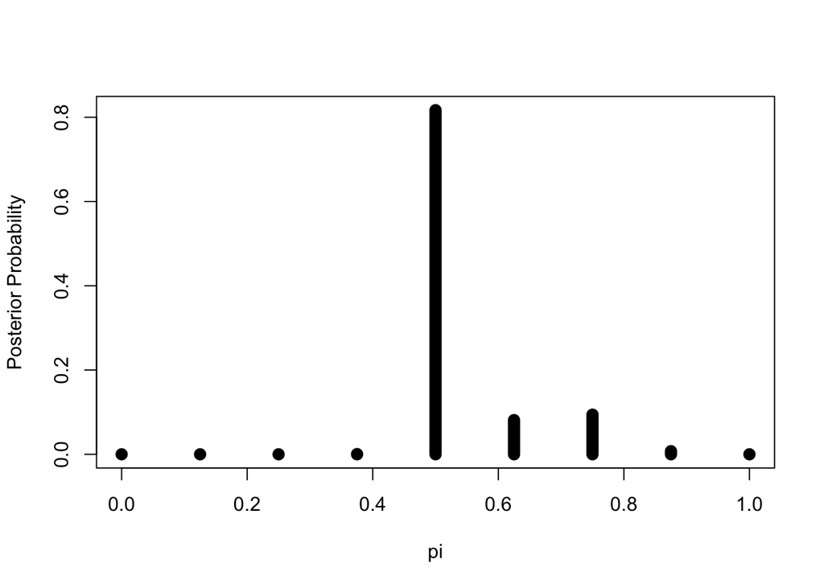

```r
pi=seq(0,1,0.125)
prior=c(.001,.002,.008,.014,.95,.014,.008,.002,.001)
L=pi^15*(1-pi)^5
unnormPost=L*prior
post=unnormPost/sum(unnormPost)
plot(pi,post,type='h',lwd=10,ylab='Posterior Probability')
```

```r
print(round(post,3))
```

```
## [1] 0.000 0.000 0.000 0.000 0.817 0.081 0.094 0.007 0.000
```

## Problem 3

### 1)

Null hypothesis: $H_0$: $\theta \le 0.2$  
Alternative hypothesis: $H_a$: $\theta > 0.2$

### 3)

$Likelihood = \binom{30}{5} \theta^{5}(1-\theta)^{25}$

For simplicity, we could exclude constact factor:

$Likelihood \propto \theta^{5}(1-\theta)^{25}$

### 4)

By consideration of beta(33,66) as prior, we would have:

$prior \propto \theta^{32}(1-\theta)^{65}$

Based on Bayes theorem:

$posterior \propto Likelihood \times prior$

Therfore we would have:

$posterir \propto \theta^{37}(1-\theta)^{90}$

### 5)

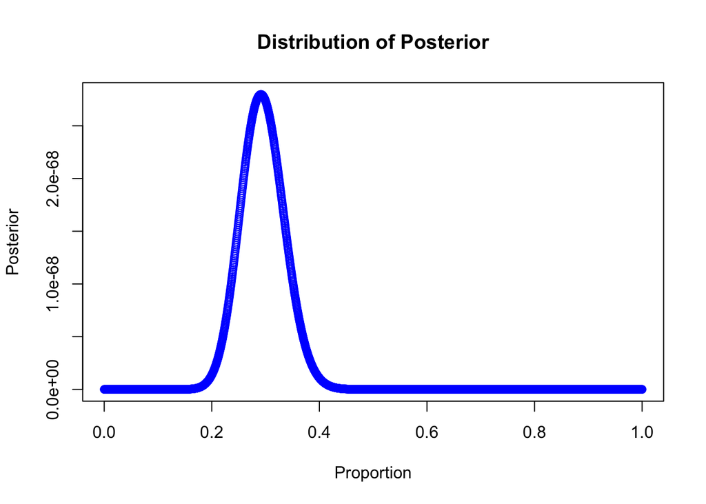

```r
theta=seq(0,1,.0004)
Posterior=beta(38,91)*theta^37*(1-theta)^90
plot(theta,Posterior,xlab="Proportion",main="Distribution of Posterior",col="blue")
```

### 6)

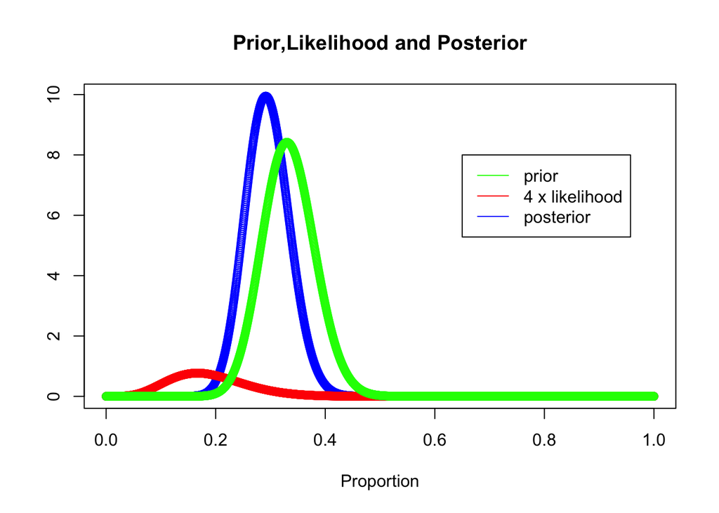

```r
# x as proportion or theta
x=seq(0,1,.0004)
prior=dbeta(x,33,66)
likelihood=choose(30,5)*x^5*(1-x)^25
posterior=dbeta(x,38,91)
plot(x,posterior,col="blue",ylab=NA,xlab="Proportion",main="Prior,Likelihood and Posterior")
points(x,4*likelihood,col="red")
points(x,prior,col="green")
legend(.65,8,legend=c("prior","4 x likelihood","posterior"),col=c("green","red","blue"),lty=c(1,1,1),ncol=1)
```

### 7)

```r
prob.null.hypothesis=pbeta(.2,38,91)
cat("Probablity of Null hypotheis is:",round(prob.null.hypothesis,3))
```

```
## Probablity of Null hypotheis is: 0.006
```

We could see that probability of null hypotheis is lower than 0.05, so with predefined level of 0.05, we would reject null hypothesis in favor of alternative hypotheis. Therfore, she will play in the first game.

### 8)

```r
alpha=38
beta=91
cred=qbeta(c(0.025,0.975),alpha,beta)
cat("95% credible interval would be:",round(cred,2))
```

```
## 95% credible interval would be: 0.22 0.38
```

### 9)

```r
mean=alpha/(alpha+beta)
median=qbeta(0.5,alpha,beta)
mode=(alpha-1)/(alpha+beta-2)
cat("Mean   of posterior is:",round(mean,4),"\n")
```

```
## Mean   of posterior is: 0.2946
```

```r
cat("Median of posterior is:",round(median,4),"\n")
```

```
## Median of posterior is: 0.2935
```

```r
cat("Mode   of posterior is:",round(mode,4),"\n")
```

```
## Mode   of posterior is: 0.2913
```

We can see that median is between mode and mean.